# GIS - Analyse met R

Jeroen Claes

11/4/2021

## GIS analyses met R

Welkom op het video kanaal van CROPLAND. Mijn naam is Jeroen Claes en ik ben een data scientist bij CROPLAND. In deze video ga ik je tonen hoe je met R geografische data kan bewerken en visualiseren op kaartjes. Ik ga je tonen hoe dit kaartje kan maken van het aantal hospitalisaties omwille van COVID-19 per provincie.

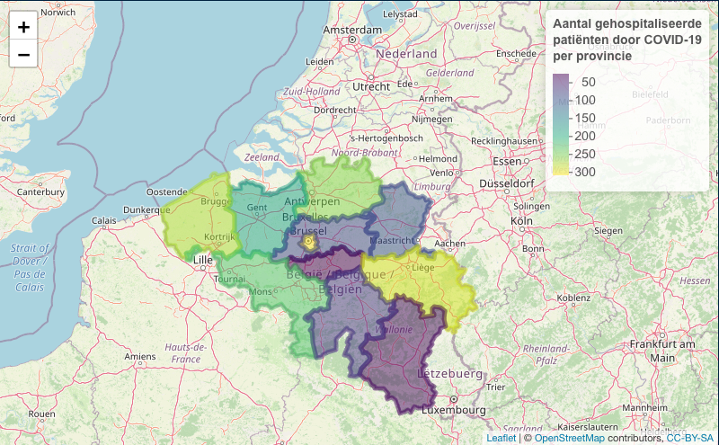

## Packages

Laten we starten met een aantal packages in te laden. Om de COVID-data te lezen, gebruiken we en CSV-reader van het readr package. Om data-bewerkingen te doen hebben we het dplyr package nodig. Om de geografische bewerkingen te doen gebruiken we het sf - simple features- package. Ten slotte hebben we ook nog het leaflet package nodig om het interactieve kaartje te maken. We gebruiken dus de commando’s library(readr), library(dplyr), library(sf) en library(leaflet)

```r
library(readr)
library(dplyr)
library(sf)
library(leaflet)
```

## Data

Voor deze oefening hebben we twee databronnen nodig. Enerzijds hebben we gegevens nodig over het aantal hospitalisaties door COVID. Deze kunnen we ophalen als CSV van de website van Scienscano(https://epistat.sciensano.be/Data/COVID19BE_HOSP.csv). Anderzijds hebben we ook informatie nodig over de provincies. Bijvoorbeeld de vormen van hun grenzen. Deze kunnen we ophalen bij https://gadm.org/ Deze website verzamelt administratieve grenzen van heel wat landen als RDS files. Dit is het eigen formaat van R om objecten op te slaan.

De data even kort bekijken, kan je met glimpse van het pakket dplyr

```
## Rows: 6,611
## Columns: 10
## $ DATE          <date> 2020-03-15, 2020-03-15, 2020-03-15, 2020-03-15, 2020-03…
## $ PROVINCE      <chr> "Antwerpen", "Brussels", "Hainaut", "Limburg", "Liège", …
## $ REGION        <chr> "Flanders", "Brussels", "Wallonia", "Flanders", "Walloni…
## $ NR_REPORTING  <dbl> 14, 15, 14, 7, 12, 3, 6, 14, 6, 2, 11, 14, 15, 14, 7, 12…
## $ TOTAL_IN      <dbl> 50, 58, 54, 20, 22, 4, 2, 16, 13, 5, 19, 63, 81, 89, 25,…
## $ TOTAL_IN_ICU  <dbl> 9, 11, 12, 6, 2, 0, 1, 5, 2, 2, 3, 12, 14, 19, 9, 2, 1, …
## $ TOTAL_IN_RESP <dbl> 4, 8, 10, 3, 1, 0, 1, 1, 0, 2, 1, 5, 11, 14, 4, 2, 1, 1,…
## $ TOTAL_IN_ECMO <dbl> 0, 0, 1, 0, 0, 0, 0, 0, 0, 0, 0, 0, 0, 1, 0, 0, 0, 0, 0,…
## $ NEW_IN        <dbl> 7, 7, 26, 9, 4, 3, 0, 5, 2, 1, 6, 10, 11, 28, 7, 2, 0, 1…
## $ NEW_OUT       <dbl> 4, 2, 1, 3, 1, 0, 0, 1, 0, 0, 2, 1, 4, 0, 0, 1, 1, 1, 0,…
```

```
## Rows: 11
## Columns: 14
## $ GID_0     <chr> "BEL", "BEL", "BEL", "BEL", "BEL", "BEL", "BEL", "BEL", "BEL…
## $ NAME_0    <chr> "Belgium", "Belgium", "Belgium", "Belgium", "Belgium", "Belg…
## $ GID_1     <chr> "BEL.1_1", "BEL.2_1", "BEL.2_1", "BEL.2_1", "BEL.2_1", "BEL.…
## $ NAME_1    <chr> "Bruxelles", "Vlaanderen", "Vlaanderen", "Vlaanderen", "Vlaa…
## $ NL_NAME_1 <chr> NA, NA, NA, NA, NA, NA, NA, NA, NA, NA, NA
## $ GID_2     <chr> "BEL.1.1_1", "BEL.2.1_1", "BEL.2.2_1", "BEL.2.3_1", "BEL.2.4…
## $ NAME_2    <chr> "Bruxelles", "Antwerpen", "Limburg", "Oost-Vlaanderen", "Vla…
## $ VARNAME_2 <chr> "Brussel Hoofstadt|Brusselse Hoofdstedelijke Gewest|Brüssel|…
## $ NL_NAME_2 <chr> NA, NA, NA, NA, NA, NA, NA, NA, NA, NA, NA
## $ TYPE_2    <chr> "Hoofdstedelijk Gewest|Région Capitale", "Provincie", "Provi…
## $ ENGTYPE_2 <chr> "Capital Region", "Province", "Province", "Province", "Provi…
## $ CC_2      <chr> NA, NA, NA, NA, NA, NA, NA, NA, NA, NA, NA
## $ HASC_2    <chr> "BE.BU", "BE.AN", "BE.LI", "BE.OV", "BE.VB", "BE.WV", "BE.BW…
## $ geometry  <MULTIPOLYGON [°]> MULTIPOLYGON (((4.403365 50..., MULTIPOLYGON (((4.963096 51.…
```

De COVID-data bevat gegevens over de hele periode van de epidemie. We gaan deze filteren zodat we voor elke provincie enkel de meest recente data overhouden. Dit kan met dplyr functies group_by en filter

```r
covid <- covid %>%
  group_by(PROVINCE) %>%
  filter(DATE == max(DATE, na.rm=TRUE))
```

We selecteren de kolommen die we nodig hebben: PROVINCE en TOTAL_IN, het totaal aantal patiënten in het ziekenhuis. Dit kunnen we doen met de dplyr functies select.

```r
covid <- covid %>%
   select(PROVINCE, TOTAL_IN)
```

Om de COVID data te kunnen verbinden aan de provincie-grenzen moeten we ervoor zorgen dat de namen van de provincies in de COVID-data overenkomen met die van de namen in de provincie-data. Dit is nu niet het geval

```r
sort(unique(covid %>% pull(PROVINCE)))
```

```
##  [1] "Antwerpen"      "BrabantWallon"  "Brussels"       "Hainaut"
##  [5] "Liège"          "Limburg"        "Luxembourg"     "Namur"
##  [9] "OostVlaanderen" "VlaamsBrabant"  "WestVlaanderen"
```

```r
sort(unique(provincies %>% pull(NAME_2)))
```

```
##  [1] "Antwerpen"       "Brabant Wallon"  "Bruxelles"       "Hainaut"
##  [5] "Liège"           "Limburg"         "Luxembourg"      "Namur"
##  [9] "Oost-Vlaanderen" "Vlaams Brabant"  "West-Vlaanderen"
```

We gebruiken de functies mutate en recode van het dplyr package om de NAME_2 kolom in de provincie-data te hercoderen naar het formaat van de COVID-data

```r
provincies <- provincies %>%
  mutate(NAME_2=recode(NAME_2, Bruxelles="Brussels", `West-Vlaanderen`="WestVlaanderen", `Oost-Vlaanderen`="OostVlaanderen", `Brabant Wallon`="BrabantWallon", `Vlaams Brabant`="VlaamsBrabant"))
```

Even controleren met de functie `identical`

```r
identical(sort(unique(covid %>% pull(PROVINCE))),sort(unique(provincies %>% pull(NAME_2))))
```

```
## [1] TRUE
```

Nu zijn we klaar om de twee datasets aan elkaar te verbinden. Dit doen we met de functie left_join uit het dplyr pakket. Aan de hand van het argument “by” kunnen we bepalen welke kolommen gebruikt worden om de data aan elkaar te verbinden.

```r
resultaat <- provincies %>%
  left_join(covid, by=c("NAME_2"="PROVINCE"))
```

## Kaartje maken

Het voordeel van onze data voor te bereiden met code bestaat erin dat we volgende week hetzelfde stukje code opnieuw kunnen laten lopen om een bijgewerkte kaart te maken. Nu zijn klaar om ons kaartje op te bouwen met het leaflet pakket. Leaflet heeft een gelaagd systeem. Dit wil zeggen dat je start van een basis-functie die een basiskaart tekent. Aan deze functie voeg je steeds lagen en functies toe. leaflet() zorgt voor een leeg map-canvas. leaflet %>% addTiles maakt een leeg map-canvas met een basis-kaart. AddPolygons voegt dan de vormen van de provincies toe.

```r
leaflet(resultaat) %>%
  addTiles() %>%
  addPolygons()
```

[interactive chart not shown]

### Kleurenpallet

Dit is al een begin. Nu moeten we enkel nog de vormen van de provincies inkleuren volgens het aantal covid-gerelateerde hospitalisaties. Om dit te doen moeten we eerst een kleurenpallet definiëren zodat de waarden uit de kolom TOTAL_IN gemapt kunnen worden op een kleurenschaal. Dit doen we met de functie colorNumeric

```r
pal <- colorNumeric(
  palette = "viridis",
  domain = resultaat$TOTAL_IN)
```

### Kleurenpallet op kaartje zetten

Dit kleurenpallet kunnen we nu gebruiken om onze kaart in te kleuren

```r
leaflet(resultaat) %>%
  addTiles() %>%
  addPolygons(color =  ~pal(TOTAL_IN), fillOpacity = 0.5)
```

[interactive chart not shown]

### Legende toevoegen

Nu zetten we nog een legende bij de kaart om ervoor te zorgen dat de resultaten interpreteerbaar zijn

```r
leaflet(resultaat) %>%
  addTiles() %>%
  addPolygons(color =  ~pal(TOTAL_IN), fillOpacity = 0.5) %>%
  addLegend(pal = pal, values = ~TOTAL_IN)
```

[interactive chart not shown]

### Titel toevoegen

Ten slotte voegen we nog een titel toe aan de legende om de resultaten wat duidelijker te maken. Ons resultaat toont duidelijk aan dat het zwaartepunt van de hospitalisaties op dit moment in het Brussels hoofdstedelijk gewest en de provincies Luik en West-Vlaanderen ligt.

```r
leaflet(resultaat) %>%
  addTiles() %>%
  addPolygons(color =  ~pal(TOTAL_IN), fillOpacity = 0.5) %>%
  addLegend(pal = pal, values = ~TOTAL_IN, title = "Aantal gehospitaliseerde<br>patiënten door COVID-19<br> per provincie")
```

[interactive chart not shown]